# Exploratory Data Analysis: Medical Insurance Costs

## 3. Initial Data Quality Review

```python
# ── Missing values ────────────────────────────────────────────────────────────
missing = df.isnull().sum()
missing_pct = (missing / len(df) * 100).round(2)
print('Missing values per column:')
print(pd.DataFrame({'Missing': missing, '% Missing': missing_pct}))
```

```
Missing values per column:
          Missing  % Missing
age             0        0.0
sex             0        0.0
bmi             0        0.0
children        0        0.0
smoker          0        0.0
region          0        0.0
charges         0        0.0
```

```python
# ── Duplicate records ─────────────────────────────────────────────────────────
n_dups = df.duplicated().sum()
print(f'Duplicate rows: {n_dups} ({n_dups / len(df) * 100:.2f}%)')
if n_dups > 0:
    print(df[df.duplicated(keep=False)].sort_values(list(df.columns)))
```

```
Duplicate rows: 1 (0.07%)
     age   sex   bmi  children smoker     region  charges
195   19  male  30.6         0     no  northwest  1639.56
581   19  male  30.6         0     no  northwest  1639.56
```

```python
# ── Unique categories in categorical columns ──────────────────────────────────
for col in cat_cols:
    print(f'{col}: {sorted(df[col].unique())}')
```

```
sex: ['female', 'male']
smoker: ['no', 'yes']
region: ['northeast', 'northwest', 'southeast', 'southwest']
```

```python
# ── Min / Max for numerical columns ──────────────────────────────────────────
bounds = df[num_cols].agg(['min', 'max']).T
print('Numerical variable ranges:')
print(bounds)
```

```
Numerical variable ranges:
              min       max
age         18.00     64.00
bmi         16.00     53.10
children     0.00      5.00
charges   1121.87  63770.43
```

```python
# ── Suspicious values — impossible or unreasonable ───────────────────────────

# BMI: values < 10 or > 60 are physiologically implausible
bmi_suspicious = df[(df['bmi'] < 10) | (df['bmi'] > 60)]

# Charges: values > 200,000 USD are outside the realistic band for the dataset;
# values below 500 USD are also extremely unlikely for annual insurance bills.
charges_high = df[df['charges'] > 200_000]
charges_low  = df[df['charges'] < 500]

# Possible missing-decimal-point errors in charges:
# A plausible annual expense range for US insurance is roughly 1,000–70,000 USD.
# Values in the hundreds of thousands could be the result of a missing decimal.
charges_suspect = df[df['charges'] > 100_000]

print(f'BMI outside [10, 60]: {len(bmi_suspicious)} rows')
print(f'Charges > 200,000: {len(charges_high)} rows')
print(f'Charges < 500: {len(charges_low)} rows')
print(f'\nRows with charges > 100,000 (potential encoding errors):')
print(charges_suspect[['age', 'sex', 'bmi', 'smoker', 'charges']].head(20))
```

```
BMI outside [10, 60]: 0 rows
Charges > 200,000: 0 rows
Charges < 500: 0 rows

Rows with charges > 100,000 (potential encoding errors):
Empty DataFrame
Columns: [age, sex, bmi, smoker, charges]
Index: []
```

**Quality Issues Detected:**

[output not shown]

## 4. Relationship Between Variables and the Target Variable

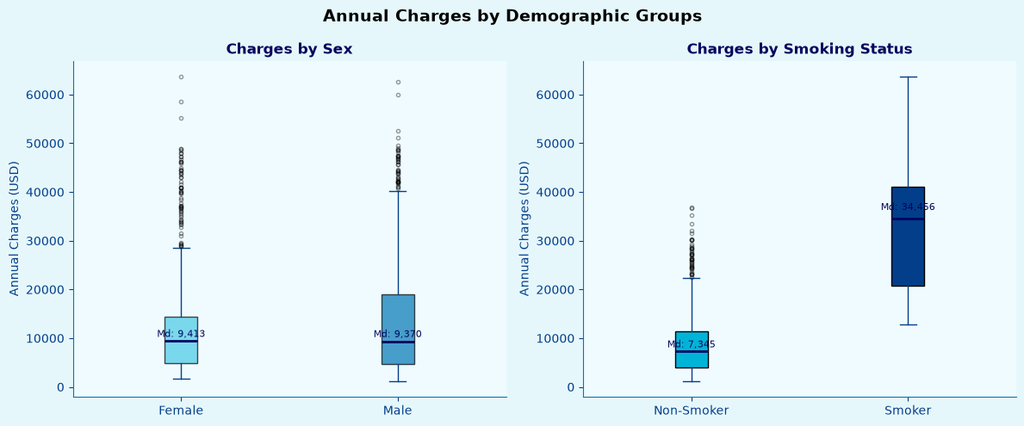

```python
# ── Boxplots: charges by sex and by smoker ────────────────────────────────────
fig, axes = plt.subplots(1, 2, figsize=(12, 5))
fig.suptitle('Annual Charges by Demographic Groups')

# — by sex
groups_sex    = [df.loc[df['sex'] == g, 'charges'] for g in ['female', 'male']]
bp1 = axes[0].boxplot(
    groups_sex, tick_labels=['Female', 'Male'],
    patch_artist=True,
    boxprops=dict(alpha=0.7),
    medianprops=dict(color=AQ['navy'], linewidth=2),
    whiskerprops=dict(color=AQ['ocean']),
    capprops=dict(color=AQ['ocean']),
    flierprops=dict(marker='o', markersize=3, alpha=0.4)
)
colors_sex = [AQ['bright'], AQ['cobalt']]
for patch, c in zip(bp1['boxes'], colors_sex):
    patch.set_facecolor(c)
axes[0].set_title('Charges by Sex')
axes[0].set_ylabel('Annual Charges (USD)')

# — by smoker
groups_smk = [df.loc[df['smoker'] == g, 'charges'] for g in ['no', 'yes']]
bp2 = axes[1].boxplot(
    groups_smk, tick_labels=['Non-Smoker', 'Smoker'],
    patch_artist=True,
    medianprops=dict(color=AQ['navy'], linewidth=2),
    whiskerprops=dict(color=AQ['ocean']),
    capprops=dict(color=AQ['ocean']),
    flierprops=dict(marker='o', markersize=3, alpha=0.4)
)
colors_smk = [AQ['aqua'], AQ['ocean']]
for patch, c in zip(bp2['boxes'], colors_smk):
    patch.set_facecolor(c)
axes[1].set_title('Charges by Smoking Status')
axes[1].set_ylabel('Annual Charges (USD)')

# Annotate medians
for ax, groups, group_labels in [
    (axes[0], groups_sex, ['Female', 'Male']),
    (axes[1], groups_smk, ['Non-Smoker', 'Smoker'])
]:
    for i, (g, lbl) in enumerate(zip(groups, group_labels), start=1):
        med = g.median()
        ax.text(i, med * 1.04, f'Md: {med:,.0f}',
                ha='center', va='bottom', fontsize=8, color=AQ['navy'])

plt.tight_layout()
plt.savefig('data/fig_charges_groups.png', dpi=150, bbox_inches='tight')
plt.show()
```

**Interpretation — Charges by Group:**

- **Sex:** The distributions for female and male beneficiaries are almost identical in central tendency and spread. Any difference in means is small compared to the within-group variance, suggesting sex alone is a weak predictor of charges.
- **Smoker:** The contrast is dramatic. Non-smokers cluster tightly at the lower end (median ≈ 7,345 USD), while smokers sit at more than four times that level (median ≈ 34,456 USD). The non-smoker box is also far narrower, indicating more predictable costs. This is the clearest visual signal in the entire dataset.

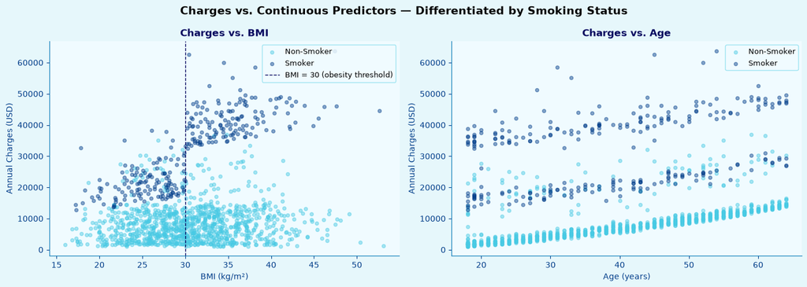

```python
# ── Scatter plots: charges vs bmi and charges vs age, coloured by smoker ──────
smoker_colors = {'no': AQ['bright'], 'yes': AQ['ocean']}

fig, axes = plt.subplots(1, 2, figsize=(14, 5))
fig.suptitle('Charges vs. Continuous Predictors — Differentiated by Smoking Status')

for smoke_val, color in smoker_colors.items():
    subset = df[df['smoker'] == smoke_val]
    lbl    = 'Smoker' if smoke_val == 'yes' else 'Non-Smoker'

    axes[0].scatter(subset['bmi'], subset['charges'],
                    color=color, alpha=0.45, s=18, label=lbl)
    axes[1].scatter(subset['age'], subset['charges'],
                    color=color, alpha=0.45, s=18, label=lbl)

axes[0].set_title('Charges vs. BMI')
axes[0].set_xlabel('BMI (kg/m²)')
axes[0].set_ylabel('Annual Charges (USD)')
axes[0].axvline(30, color=AQ['navy'], linestyle='--', linewidth=1,
                label='BMI = 30 (obesity threshold)')
axes[0].legend(fontsize=9)

axes[1].set_title('Charges vs. Age')
axes[1].set_xlabel('Age (years)')
axes[1].set_ylabel('Annual Charges (USD)')
axes[1].legend(fontsize=9)

plt.tight_layout()
plt.savefig('data/fig_scatter_bmi_age.png', dpi=150, bbox_inches='tight')
plt.show()
```

**Interpretation — Scatter Plots:**

- **Charges vs. BMI:** Non-smokers (light dots) populate a wide, relatively flat band regardless of BMI. Smokers (dark dots), by contrast, split into two distinct sub-clouds: those with BMI below ~30 cluster around 20,000–30,000 USD, while those above BMI 30 jump to 35,000–65,000 USD. This interaction between `smoker` and `bmi` suggests that a combined feature (e.g., `obese_smoker`) would be informative in a regression model.
- **Charges vs. Age:** Three nearly parallel bands emerge. The bottom band is non-smokers; the top two bands are smokers stratified by BMI. In all three, charges trend upward with age at a moderate rate. The age effect is real but smaller than the smoking effect.